# Machine learning Assignment

## Cross-validation

Finally the resulted model was used to generate predictions using the validation set for both cases.

```r
validpred <- predict(rfMod, validSS)
confusionMatrix(validpred, validSS$classe)$overall
```

```
##       Accuracy          Kappa  AccuracyLower  AccuracyUpper   AccuracyNull
##      0.9904843      0.9879625      0.9876606      0.9928041      0.2844520
## AccuracyPValue  McnemarPValue
##      0.0000000            NaN
```

```r
validpred <- predict(rfMod2, valid_na)
confusionMatrix(validpred, valid_na$classe)$overall
```

```
##       Accuracy          Kappa  AccuracyLower  AccuracyUpper   AccuracyNull
##   7.500000e-01   6.834392e-01   6.339719e-01   8.446073e-01   2.500000e-01
## AccuracyPValue  McnemarPValue
##   8.070606e-19            NaN
```

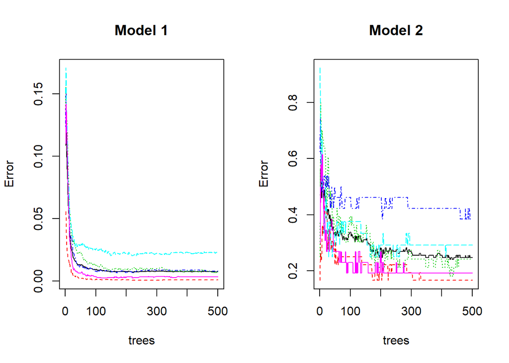

```r
par(mfrow=c(1,2))
plot(rfMod, main="Model 1")
plot(rfMod2, main="Model 2")
```

The higher accuracy was obtained using only predictors **without NA predictors**. Omitting NA values, but still using the remaning observations resulted less accurate. Model 1 could even be tuned since in the figure, it can be seen that only **200 trees** were needed to reach a **minimum error**.

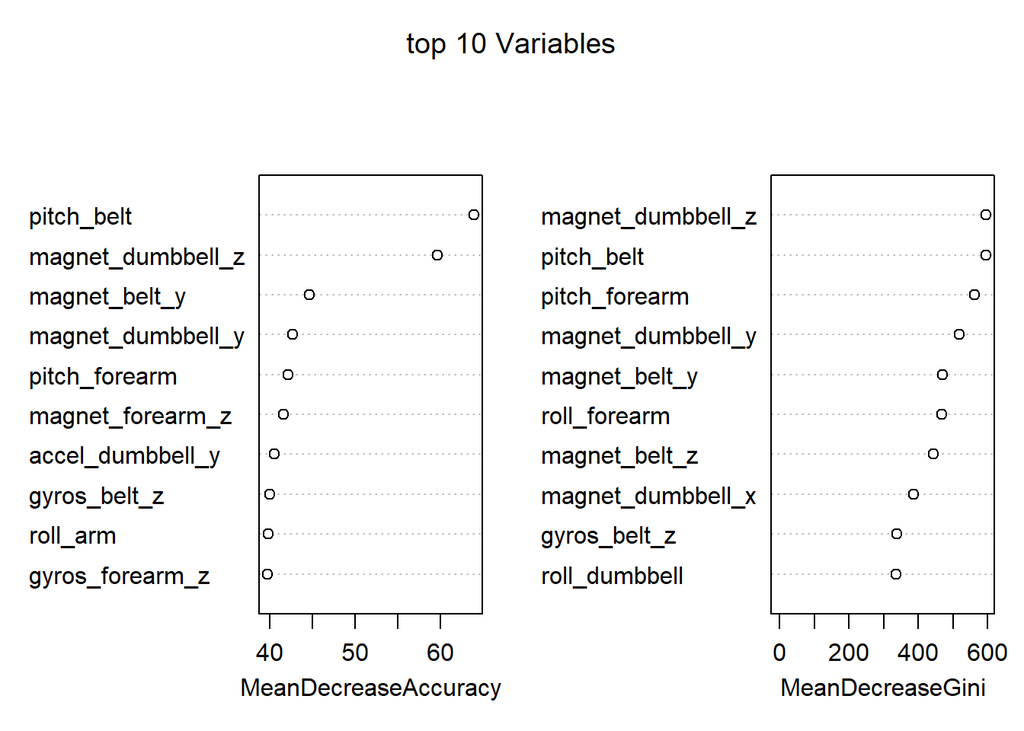

```r
varImpPlot(rfMod,sort=T,n.var=10,main="top 10 Variables")
```

## Test set prediction

Finally the model is tested using the external data as it is.

```r
predtest<-predict(rfMod,testing)
print(predtest)
```

```
##  1  2  3  4  5  6  7  8  9 10 11 12 13 14 15 16 17 18 19 20
##  B  A  B  A  A  E  D  B  A  A  B  C  B  A  E  E  A  B  B  B
## Levels: A B C D E
```